# Boston housing example

R’s fastshap vs. Python’s shap

Brandon M. Greenwell

August 16, 2019

In this notebook we compare fastshap with the shap Python module. In particular, we’ll compare `fastshap::explain()` with the `shap.SamplingExplainer()` method which provides the same Monte Carlo approach to computing ApproxSHAP (ApproxSHAP) values described in Štrumbelj and Kononenko (2014); in particular, see **Algorithm 1**. We’ll also compare `fastshap::explain()` with the results from `shap.TreeExplainer()` which produces exact Shapley (ExactSHAP or TreeSHAP if referring specifically to the implementation for tree-based models) values for a wide variety of tree-based models in Python (Lundberg et al. 2019). The comparisons will be made on a random forest trained to the Boston housing data set (the data are available in the `notebooks/data` directory within this repository).

## TL;DR

- The shap library treats the specified number of Monte Carlo repetitions as a total and breaks distributes them across the feature columns according to variance. There does not seem to be any way to override this; to me, this is confusing and not optimal in all cases. fastshap on the other hand, uses the same number of Monte Carlo repetitions on all columns (though, this can be wasteful compared to shap’s approach). Hence, it is difficult to compare the actual computation time between the two packages in a fair way.
- TreeSHAP (provided by `shap.TreeExplainer()`) does not scale well with tree depth and will likely take longer than fastshap’s fast Monte Carlo approach for bagged decision trees and random forests (where trees are intentionally grown deep).
- fastshap is quicker compared to most other implementations of ApproxSHAP because it makes far less calls to the underlying prediction function by working on an entire column of ApproxSHAP values at a time. It’s also partially written in C++ and makes efficient use of logical subsetting.

## fastshap

To start, we’ll load all the required packages and prep the Boston housing data:

```r
# Load required packages
library(fastshap)  # for explain() function
library(ggplot2)   # for autoplot() function
library(ranger)    # for efficiently fitting random forests

# Set up the Boston housing data
boston <- read.csv("data/boston.csv")
X <- data.matrix(subset(boston, select = -cmedv))
```

Next, we train a random forest and create a simple prediction wrapper to be used by `explain()`:

```r
# Train a random forest
set.seed(944)  # for reproducibility
(rfo <- ranger(cmedv ~ ., data = boston))
```

```
## Ranger result
##
## Call:
##  ranger(cmedv ~ ., data = boston)
##
## Type:                             Regression
## Number of trees:                  500
## Sample size:                      506
## Number of independent variables:  15
## Mtry:                             3
## Target node size:                 5
## Variable importance mode:         none
## Splitrule:                        variance
## OOB prediction error (MSE):       10.11608
## R squared (OOB):                  0.8800166
```

```r
# Prediction wrappers
pfun <- function(object, newdata) {
  predict(object, data = newdata)$predictions
}
```

```r
# Comput ApproxSHAP values
set.seed(945)  # for reproducibility
t1 <- system.time(  # time the results
  res_fastshap <- explain(rfo, X = X, nsim = 100, pred_wrapper = pfun)
)

# Print results
res_fastshap
```

```
## # A tibble: 506 x 15
##       lon      lat   crim       zn  indus     chas   nox     rm     age
##     <dbl>    <dbl>  <dbl>    <dbl>  <dbl>    <dbl> <dbl>  <dbl>   <dbl>
##  1 -1.06   0.147   0.199   0.0583   0.809 -0.0297  0.136 -0.699  0.0322
##  2 -1.00  -0.0290  0.0835 -0.0341  -0.147 -0.0132  0.246 -0.714 -0.165
##  3 -0.809  0.0577  0.357   0.00292 -0.129 -0.0399  0.645  4.49   0.103
##  4 -0.733  0.00357 0.340  -0.0139   1.01  -0.00726 0.480  2.91   0.275
##  5 -0.740  0.186   0.349  -0.0416   1.53  -0.0297  0.776  4.39   0.299
##  6 -0.553  0.0993  0.400   0.00156  1.35  -0.0362  0.465 -0.602  0.213
##  7 -0.751  0.172   0.408  -0.0231  -0.143 -0.0348  0.229 -1.51   0.333
##  8 -0.832  0.102   0.550  -0.0567  -0.289 -0.0749  0.337 -0.917 -0.315
##  9 -1.13  -0.129   0.140  -0.0549  -0.258 -0.0442  0.129 -2.14  -0.606
## 10 -0.759 -0.121   0.305  -0.0634  -0.309 -0.0375  0.211 -1.29  -0.256
## # … with 496 more rows, and 6 more variables: dis <dbl>, rad <dbl>,
## #   tax <dbl>, ptratio <dbl>, b <dbl>, lstat <dbl>
```

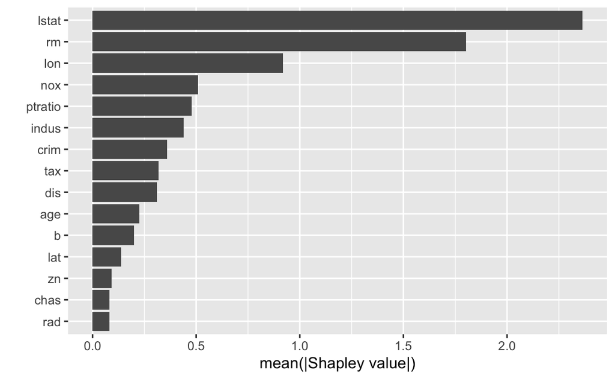

```r
# Plot results
autoplot(res_fastshap)
```